# Test 1, STAT 245 for iw3

STAT 245, Spring 2024

## Context

In 2021, Keren Levy and colleagues published the paper, [*Lifelong exposure to artificial light at night impacts stridulation and locomotion activity patterns in the cricket* Gryllus bimaculatus](https://royalsocietypublishing.org/doi/full/10.1098/rspb.2021.1626?af=R). They state,

> > Living organisms experience a worldwide continuous increase in artificial light at night (ALAN), negatively affecting their behaviour. The field cricket, an established model in physiology and behaviour, can provide insights into the effect of ALAN on insect behaviour. The stridulation [sound making] and locomotion [movement] patterns of adult male crickets reared under different lifelong ALAN intensities were monitored simultaneously for five consecutive days.

Researchers also measured the size and condition of the crickets. Variables in the dataset include:

- `night_light_level` Each cricket was exposed to 12 hours of daylight in the daytime; this variable tells what happened at night. They were either in darkness, low light, medium light, or daylight.
- `body_weight_g` weight in grams
- `body_length_mm` length in mm
- `right_wing_length` in mm (see diagram below if you want to know which body part is what)
- `right_tibia_length` in mm
- `right_femur_length` in mm
- `head_width` in mm
- `pronotum_length` in mm
- `pronotum_width` in mm
- `body_condition_index` a measure of the physical health of the cricket based on its measurements

(*Please ignore any other variables in the dataset that are not in the list above!*)

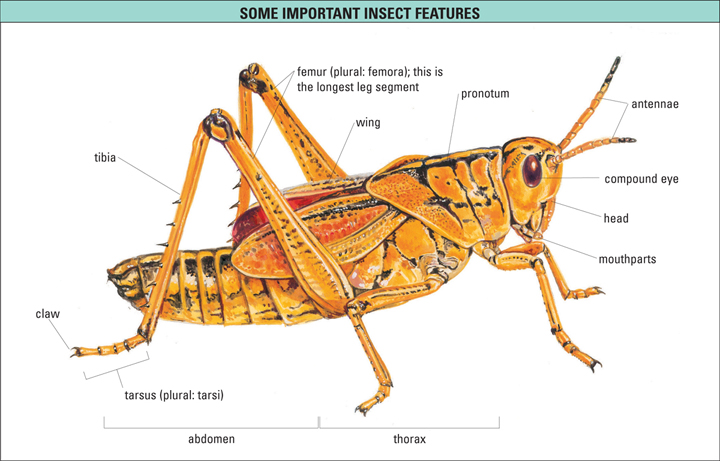

## Research Question

Is there an association between the `body_condition_index` and the `night_light_level`?

## Data Access

You can find your data at: https://sldr.netlify.app/data/crickets.csv